# Mapping benthic habitat sensitivity to fishing activities

Philip Haupt & Duncan Vaughan

25 February 2019

# Introduction

The United Kingdom’s (UK) benthic habitat is a critical component of the marine ecosystem which supports a rich fish and benthic invertebrate communit.

The benthic habitat is subject to a vast array of pressures in the marine environment, of which bottom towed fishing gears is the most prevalent and widesread acitvities.

Fishing regulations may change in due process when the UK leaves the EU (EU exit) on the 31 March 2019, which is likely to have substantial ramifications for fisheries and fisheries management *(Appleby and Harrison, 2017)*. The Queen’s speech indicated that a new Fisheries Bill would be drafted to set domestic fishing quotas, and preserve fishing stocks (https://www.instituteforgovernment.org.uk/explainers/queens-speech). A change to fishing regulations requires that due consideration be given to the impacts of a displacement of fishing effort on the environment and to livelihoods of fishermen *(ABPmer, 2017; Guidetti, 2007)*. A displacement of fishing effort is defined here as the new or different areas where fishing effort moves to, which may be accompanied by a change in fishing gear used, in response to a change in fishing regulations (Vaughan, 2017). Previous research (studies) have shown that a displacement of fishing effort could lead to detrimental environmental and socio-economic effects (Bastardie et al., 2017; Chollet and Mumby, 2015). The overarching aim of this project is provide advice to fisheries managers to minimise damage to UK marine ecosystems by avoiding negative impacts on the ecosystem arising from the displacement of fishing effort from the various [inshore] fisheries. Specifically, the project aims to identify recently non-fished sensitive benthic habitat, and essential fish habitat which are currently only lightly impacted, or not impacted.

### Objectives

The objective of the project is to map the spatial distribution of sensitive benthic habitat in relation to 36 OSPAR standardized pressures caused by fishing activities in English territorial waters (12 NM offshore). and their corresponding pressures to inform Natural England’s Conservation Advice. The study area includes the wider seas (outside of MPAs) to provide evidence of sensitive habitats which may be affected by a displacement of fishing pressures arising from different scenarios of EU Exit. A secondary aim for the project is develop a consolidated spatial index of the combined suite of pressures stemming from each fishing activity to provide a summarised overview of benthic habitat sensitivity to inform NE’s conservation advice. A third project objective is the development of maps of the sensitivity distribution for 30 fish and shellfish species within UK waters to fishing related activities. These models are underpinned by sensitivity assessments carried out at set benchmarks, and coupled with species distribution models. A fourth objective is to link the work to policy on Sustainable Fishing within English territorial waters to provide high level direction to Natural England. Specifically this component will help develop the principles which inform advice on sustainable fishing in English territorial waters. This part of the project will attempt to develop a clear understanding of how sensitivity maps can be used to inform sustainable fishing policy and practice.

Fishing displacement models have been developed previously (Bastardie, Nielsen, and Miethe 2013).

# Methods

## Study Area

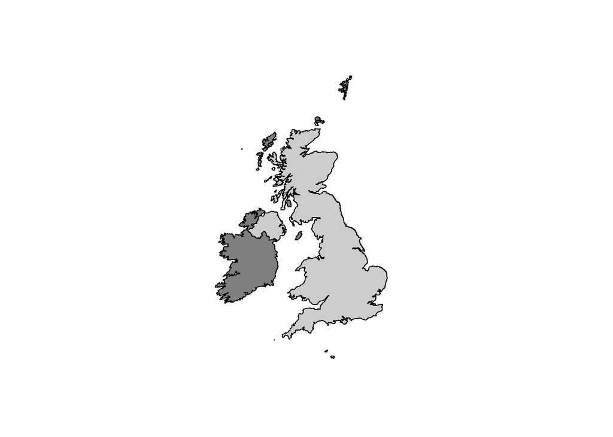

### Data sources

Two main data sources were used to map out marine benthic biotope sensitivities for the UK’s EEZ, namely 1) sensitivity assessments, and 2) marine biotope map for the UK. The two data sources share common unique identifier, namely the EUNIS code, which referes to the biotope or habitat.

### Data processing

All technical work is being carried out using the R statistical environment in effort to make the work repeatable and provide instant results following updates to sensitivity assessments or updates to the benthic habitat map.

## References

Bastardie, Francois, J Rasmus Nielsen, and Tanja Miethe. 2013. “DISPLACE: A Dynamic, Individual-Based Model for Spatial Fishing Planning and Effort Displacement—integrating Underlying Fish Population Models.” *Canadian Journal of Fisheries and Aquatic Sciences* 71 (3). NRC Research Press: 366–86.

Groot, Jiska de, Maria Campbell, Matthew Ashley, and Lynda Rodwell. 2014. “Investigating the Co-Existence of Fisheries and Offshore Renewable Energy in the Uk: Identification of a Mitigation Agenda for Fishing Effort Displacement.” *Ocean & Coastal Management* 102. Elsevier: 7–18.

Vaughan, Duncan. 2017. “Fishing Effort Displacement and the Consequences of Implementing Marine Protected Area Management – an English Perspective.” *Marine Policy* 84: 228–34. doi:10.1016/j.marpol.2017.07.007.